# hw6-Deep-Bhalodia

Deep Bhalodia

4/3/2019

### Importing required packages

```r
library(purrr)
library(tidyr)
library(tidyverse)
library(dplyr)
library(tidytext)
library(tokenizers)
library(stringr)
library(modelr)
library(mlbench)
```

### Problem 1

### Write a function that performs cross-validation for a linear model (fit using lm) and returns the average root-mean-square-error across all folds.

```r
cvlm <- function(formula, data, nfold) {
  cvdata <- crossv_kfold(data, nfold)
  cvdata <- cvdata %>%
  mutate(fit = map(train, ~ lm(formula, data = .))) %>%
  mutate(rmse = map2_dbl(fit, test, rmse))
  c(cv_rmse=mean(cvdata$rmse))
}
```

### Problem 2

### Using 5-fold cross-validation, report the cross-validated RMSE of the model you fit in Homework 5, Problem 5, for predicting crim from the BostonHousing dataset in the mlbench package. Can you find a model with a better cross-valided RMSE?

```r
set.seed(1)

data("BostonHousing")

cvlm(log(crim) ~ log(dis) + rad,data=BostonHousing, nfold=5)
```

```
##   cv_rmse
## 0.8916171
```

```r
cvlm(log(crim) ~ log(dis) + rad + chas,data=BostonHousing, nfold=5)
```

```
##   cv_rmse
## 0.8894011
```

```r
cvlm(log(crim) ~ log(dis) + rad + tax,data=BostonHousing, nfold=5)
```

```
##   cv_rmse
## 0.8960458
```

```r
cvlm(log(crim) ~ log(dis) + rad + ptratio, data=BostonHousing, nfold=5)
```

```
## cv_rmse
## 0.89996
```

```r
cvlm(log(crim) ~ log(dis) + rad + tax + ptratio, data=BostonHousing, nfold=5)
```

```
##   cv_rmse
## 0.8937894
```

### Problem 3

### Import the text from all 56 Donald Trump speeches into R. Tokenize the data into a tidy text data frame, using bigrams as tokens.

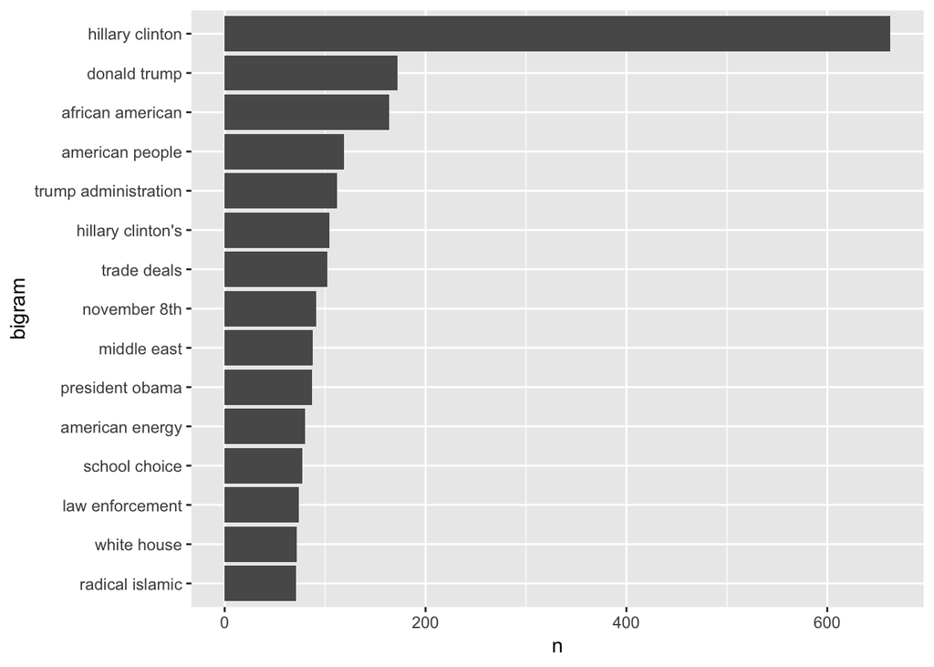

```r
text <- read_lines("full_speech.txt")


trump <- tibble(line=1:length(text), text=text)


trump_bigrams <- trump %>%
  unnest_tokens(bigram, text, token="ngrams", n=2) %>%
  separate(bigram, c("word1", "word2"), sep = " ")


trump_bigrams %>%
  filter(!word1 %in% c(stop_words$word, "applause")) %>%
  filter(!word1 %in% c("not", "no", "never", "without")) %>%
  filter(!word2 %in% c(stop_words$word, "applause")) %>%
  unite(bigram, word1, word2, sep = " ") %>%
  count(bigram, sort=TRUE) %>%
  mutate(bigram = reorder(bigram, n)) %>%
  top_n(15) %>%
  ggplot(aes(x=bigram, y=n)) +
  geom_col() +
  coord_flip()
```

### Problem 4

### We would like to see the most commonly negated words in Donald Trump’s speeches, and how they’re negated.

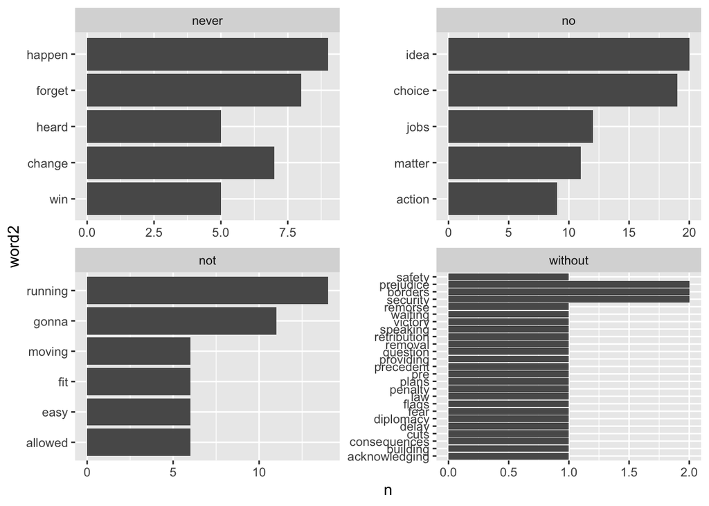

```r
trump_bigrams %>%
  filter(word1 %in% c("not", "no", "never", "without")) %>%
  filter(!word2 %in% c(stop_words$word, "applause")) %>%
  count(word1, word2, sort=TRUE) %>%
  mutate(word2 = reorder(word2, n)) %>%
  group_by(word1) %>%
  top_n(5) %>%
  ggplot(aes(x=word2, y=n)) +
  geom_col() +
  facet_wrap(~word1, scales="free") +
  coord_flip()
```

### Problem 5

### We would like to do a sentiment analysis of Donald Trump’s speeches. In order to make sure sentiments are assigned to appropriate contexts, first tokenize the speeches into bigrams, and filter out all bigrams where the first word is any of the words “not”, “no”, “never”, or “without”.

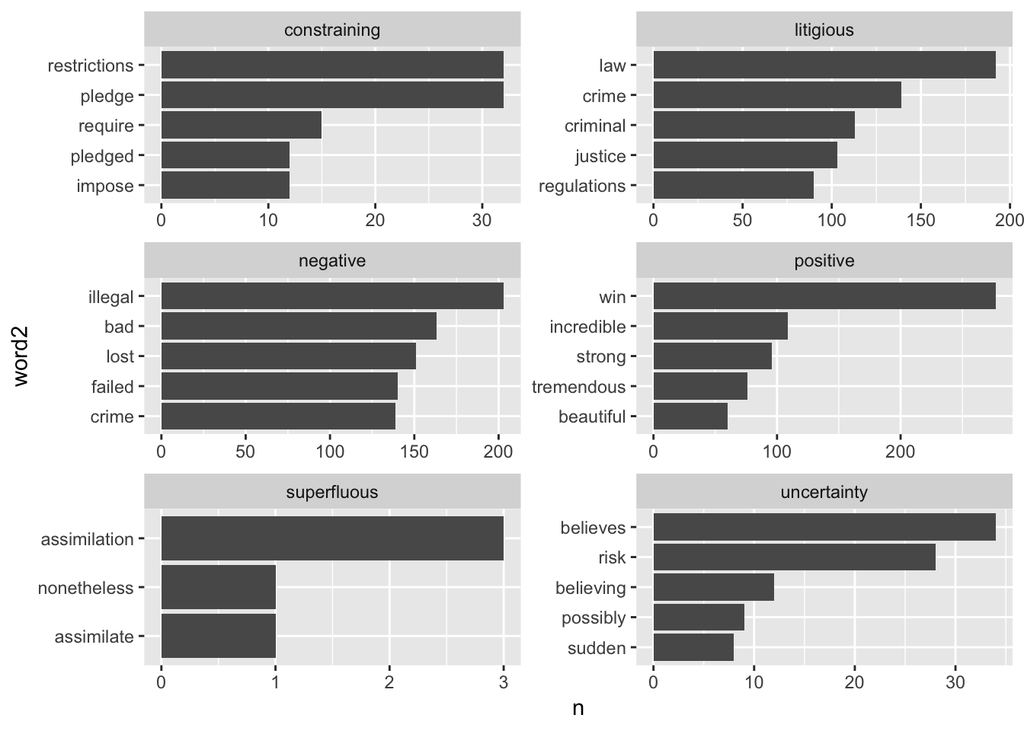

```r
trump_bigrams %>%
  filter(!word1 %in% c("not", "no", "never", "without")) %>%
  filter(!word2 %in% c(stop_words$word, "applause")) %>%
  inner_join(get_sentiments("loughran"), by=c("word2"="word")) %>%
  count(word2, sentiment, sort=TRUE) %>%
  mutate(word2 = reorder(word2, n)) %>%
  group_by(sentiment) %>%
  top_n(5) %>%
  ggplot(aes(x=word2, y=n)) +
  geom_col(show.legend=FALSE) +
  facet_wrap(~sentiment, ncol=2, scales="free") +
  coord_flip()
```